```python
# pip install nltk
# pip install --upgrade gensim
# pip install keras

import pandas as pd
import numpy as np
import seaborn as sns
import matplotlib.pyplot as plt
import nltk
# import nltk.corpus
from nltk.text import Text
from nltk.stem import PorterStemmer, LancasterStemmer, WordNetLemmatizer
from nltk.corpus import stopwords
# from nltk.corpus import brown
# nltk.download() # doesn't download anything; opens the graphical window where you can download something
# nltk.download('punkt')
# nltk.download('wordnet')
# nltk.download('stopwords')
# nltk.download('words')
# nltk.download('averaged_perceptron_tagger') # for a test related to the project

from nltk.corpus import wordnet # as wn
from nltk.stem.wordnet import WordNetLemmatizer as WNL
from collections import defaultdict

from sklearn.feature_extraction.text import TfidfVectorizer, CountVectorizer
from sklearn.decomposition import LatentDirichletAllocation, NMF

from yellowbrick.text import TSNEVisualizer
from yellowbrick.text.tsne import tsne
from sklearn import manifold

from seaborn import color_palette, palplot, scatterplot, set_style
set_style('white')

from sklearn.preprocessing import StandardScaler
from sklearn.decomposition import PCA

from sklearn import cluster, metrics
from sklearn.mixture import GaussianMixture

%matplotlib inline
from os import listdir
from matplotlib.image import imread
import cv2
import time
from sklearn import manifold, decomposition

from gensim.models import Word2Vec

# conda install -c menpo opencv3
# pip install opencv-python
# pip install opencv-contrib-python

## import os
# import random
# import re
# import string

# import gensim

# import logging
# logging.basicConfig(format='%(asctime)s : %(levelname)s : %(message)s', level=logging.INFO)
import gensim.downloader as api

from tensorflow.keras.applications.vgg16 import VGG16
from tensorflow.keras.preprocessing.image import load_img, img_to_array
from tensorflow.keras.applications.vgg16 import preprocess_input

from tensorflow.keras.layers import Dense
from tensorflow.keras import Model

from tensorflow.keras.applications.vgg16 import decode_predictions

from tensorflow.keras.utils import to_categorical
from tensorflow.keras.applications.vgg16 import VGG16
from tensorflow.keras.applications.vgg16 import preprocess_input
from tensorflow.keras import layers, models
from tensorflow.keras.callbacks import EarlyStopping

# initially it was just 'path'
path_images = 'C:\\Users\\Veronika\\DATABASES\\p6_image_classification\\Images\\'
path_text = 'C:\\Users\\Veronika\\DATABASES\\p6_image_classification\\'
```

```python
%who_ls
```

[output not shown]

# Questions

1. user warning: *c* argument looks like a single numeric RGB or RGBA sequence, which should be avoided as value-mapping will have precedence in case its length matches with *x* & *y*. Please use the *color* keyword-argument or provide a 2-D array with a single row if you intend to specify the same RGB or RGBA value for all points.

j'ai mis les arguments "color", "colors", "color_palette" et "c", le tSNE-Visualizer soit les ignore, soit lève une erreur. Donc le programme marche correctement, mais il lève toujours cet avertissment.

1. Section "Visualization with t-SNE calculation and scatterplot": ValueError: 'init' must be 'pca', 'random', or a numpy array. Ici on parle de quel tableau ? (si "numpy array" s'appelle bien un tableau en français" ça peut être par exemple quoi? Ce tableau peut venir d'où?
2. **La nouvelle question et la plus importante:** IN 125: error: OpenCV(4.5.4) D:\a\opencv-python\opencv-python\opencv\modules\core\src\alloc.cpp:73: error: (-4:Insufficient memory) Failed to allocate 1498885248 bytes in function 'cv::OutOfMemoryError'

je pense qu'il n'a pas assez de memoir pour executer à la fois Word2Vec (qui demande le telechargement de base de vectoirs du poids 1.5 gigas) et calcul de descripteurs SIFT. Quand je couvre tout le bloc Word2Vec en commentaire, le code en IN 125 (calcul de descripteurs SIFT) s'execute sans soucis.

Pour solution, j'ai tésté de supprimer la variable associé avec la base de vectors (la variable qui s'appelle wv) et les variables qui utilisent cette variables (les fonctions "mean_word_vectors" et "word2vec_pipeline". Mais ça n'a pas aidé. Toujours le même erreur s'elève.

Y a-t-il un moyen de supprimer de mémoire des variables ou autres morceaux de code que l'on n'utilise plus, pour libérer d'espace mémoire?

L'utilisation de mémoire n'est pas constante: elle fait des "vagues" près d'image 300. Mais le programme survie cette vague: l'utilisation de mémoire rebaisse comme avant la "vague", et le programme continue s'executer. Puis près d'image 400 il y a une deuxième "vague": l'utilisation de mémoire monte. Mais cette fois le programme ne survie la vague que à condition que je n'avais pas encore executé avant le Word2Vec.

# Load the database

```python
descri = pd.read_csv(path_text + 'flipkart.csv')
```

```python
descri.info()
```

```
<class 'pandas.core.frame.DataFrame'>
RangeIndex: 1050 entries, 0 to 1049
Data columns (total 15 columns):
 #   Column                   Non-Null Count  Dtype
---  ------                   --------------  -----
 0   uniq_id                  1050 non-null   object
 1   crawl_timestamp          1050 non-null   object
 2   product_url              1050 non-null   object
 3   product_name             1050 non-null   object
 4   product_category_tree    1050 non-null   object
 5   pid                      1050 non-null   object
 6   retail_price             1049 non-null   float64
 7   discounted_price         1049 non-null   float64
 8   image                    1050 non-null   object
 9   is_FK_Advantage_product  1050 non-null   bool
 10  description              1050 non-null   object
 11  product_rating           1050 non-null   object
 12  overall_rating           1050 non-null   object
 13  brand                    712 non-null    object
 14  product_specifications   1049 non-null   object
dtypes: bool(1), float64(2), object(12)
memory usage: 116.0+ KB
```

```python
descri.tail(3)
```

|  | uniq_id | crawl_timestamp | product_url | product_name | product_category_tree | pid | retail_price | discounted_price | image | is_FK_Advantage_product | description | product_rating | overall_rating | brand | product_specifications |
| --- | --- | --- | --- | --- | --- | --- | --- | --- | --- | --- | --- | --- | --- | --- | --- |
| 1047 | 5912e037d12774bb73a2048f35a00009 | 2015-12-01 10:15:43 +0000 | http://www.flipkart.com/uberlyfe-extra-large-p... | Uberlyfe Extra Large Pigmented Polyvinyl Films... | ["Baby Care >> Baby & Kids Gifts >> Stickers >... | STIE5UVGW2JWVWCT | 4500.0 | 1449.0 | 5912e037d12774bb73a2048f35a00009.jpg | False | Buy Uberlyfe Extra Large Pigmented Polyvinyl F... | No rating available | No rating available | Uberlyfe | {"product_specification"=>[{"key"=>"Number of ... |
| 1048 | c3edc504d1b4f0ba6224fa53a43a7ad6 | 2015-12-01 10:15:43 +0000 | http://www.flipkart.com/wallmantra-medium-viny... | Wallmantra Medium Vinyl Sticker Sticker | ["Baby Care >> Baby & Kids Gifts >> Stickers >... | STIEC889ZGFD3RCE | 3465.0 | 1333.0 | c3edc504d1b4f0ba6224fa53a43a7ad6.jpg | False | Buy Wallmantra Medium Vinyl Sticker Sticker fo... | No rating available | No rating available | Wallmantra | {"product_specification"=>[{"key"=>"Number of ... |
| 1049 | f2f027ad6a6df617c9f125173da71e44 | 2015-12-01 10:15:43 +0000 | http://www.flipkart.com/uberlyfe-large-vinyl-s... | Uberlyfe Large Vinyl Sticker | ["Baby Care >> Baby & Kids Gifts >> Stickers >... | STIE2ZEPACRQJKH7 | 1190.0 | 595.0 | f2f027ad6a6df617c9f125173da71e44.jpg | False | Buy Uberlyfe Large Vinyl Sticker for Rs.595 on... | 4 | 4 | Uberlyfe | {"product_specification"=>[{"key"=>"Sales Pack... |

```python
# pd.get_option('display.max_colwidth') # 50
pd.set_option('display.max_colwidth', None)

descri.loc[descri.retail_price.isna(), 'product_url']
# the internet page is correct, as others

descri.loc[descri.product_specifications.isna(), 'product_url']
# the internet page is correct, as others

pd.set_option('display.max_colwidth', 50)

# descri.product_rating.value_counts() # no_rating_available 889 out of 1050
# descri.overall_rating.value_counts() # no_rating_available 889 out of 1050
descri.product_category_tree[50]
```

```
'["Kitchen & Dining >> Coffee Mugs >> AKUP Coffee Mugs >> AKUP life-is-not-living Ceramic Mug (300 ml)"]'
```

```python
keep_cols = ['image', 'product_name', 'product_category_tree', 'description']
# keep_cols = ['product_url', 'product_name',
#        'product_category_tree',
#        'image', 'description',
#        'brand', 'product_specifications']

# descri['only_descri'] = descri.description
# descri['description'] = descri.product_name + ' ' + descri.description
# keep_cols = ['product_category_tree', 'only_descri', 'description']

# descri['description'] = descri.product_name + ' ' + descri.description
```

```python
descri = descri[keep_cols]
```

# Extraction of general category from column "product_category_tree"

Before I get my own labels from clustering (by KMeans or other methods) I can use the "general category" as labels.

```python
# descri.product_category_tree[0]
# descri.product_category_tree[0].strip('[""]')
# descri.product_category_tree[0].strip('[""]').split(' >> ')
descri['full_category'] = descri.product_category_tree.str.strip('[""]').str.split(' >> ')
descri['full_category'][0][0]
```

```
'Home Furnishing'
```

```python
# descri['general_category'] = descri['full_category'].apply(lambda x: x[0])
descri['general_category'] = descri['full_category'].str.get(0)
descri.general_category.value_counts()
```

```
Home Furnishing               150
Baby Care                     150
Watches                       150
Home Decor & Festive Needs    150
Kitchen & Dining              150
Beauty and Personal Care      150
Computers                     150
Name: general_category, dtype: int64
```

Vu que le nombre d'objets est le même partout, dans chaque catégorie, je suppose que cet echantillon était sélectionné comme ça exprès. Donc dans la classification il y a du sens dans l'approche à se cibler à 7 catégories qui se rapproches à les categories qu'on a extrait.

```python
labels_names = list(descri.general_category.unique())
descri['label'] = 0

for name, i in zip(labels_names, range(7)):
    descri.loc[descri.general_category == name, 'label'] = i

# descri['sub_category'] = descri['full_category'].apply(lambda x: x[1])
descri['sub_category'] = descri['full_category'].str.get(1)

descri[descri.general_category == 'Watches'].sub_category.value_counts()
# descri[descri.general_category == 'Computers'].sub_category.value_counts()
# descri[descri.general_category == 'Home Furnishing'].sub_category.value_counts()
# descri[descri.general_category == 'Home Decor & Festive Needs'].sub_category.value_counts()
# descri[descri.general_category == 'Beauty and Personal Care'].sub_category.value_counts()
# descri[descri.general_category == 'Kitchen & Dining'].sub_category.value_counts()
# descri[descri.general_category == 'Baby Care'].sub_category.value_counts()
```

```
Wrist Watches    149
Clocks             1
Name: sub_category, dtype: int64
```

```python
orig_labels = descri.label.values
orig_labels_names = descri.general_category.values
descri['image_fullpath'] = path_images + descri.image
descri.image_fullpath[0]
```

```
'C:\\Users\\Veronika\\DATABASES\\p6_image_classification\\Images\\55b85ea15a1536d46b7190ad6fff8ce7.jpg'
```

# Image classification

It doesn't matter for the outcome of the project whether you treat images first or text first. Here I started with image treatment in order to handle one image with size 8484 * 11042 pixels. It works fine when I treat the images before text, with its Word2Vec vectors base of 1.6 Gb of memory uptaken.

To install the package cv2 (it's the same that opencv) with conda run: conda install -c menpo opencv3

Install cv2 through conda prompt is a bad idea, because the latest version which is available through Conda prompt is 4.0.1, which is under patent. The latest of all existing versions is 4.5.4, which is no more under patent. That patent has been expired in March (or July) 2020. To install the version 4.5.4, use pip command through Jupyter notebook.

pip install opencv-python

pip install opencv-contrib-python

```
Home Furnishing
```

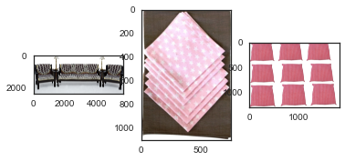

```
Baby Care
```

[figure not shown]

```
Watches
```

[figure not shown]

```
Home Decor & Festive Needs
```

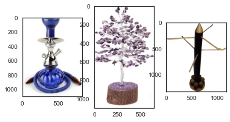

```
Kitchen & Dining
```

[figure not shown]

```
Beauty and Personal Care
```

[figure not shown]

```
Computers
```

[figure not shown]

```python
def list_fct(name) :
    return list(descri[descri.general_category == name].image.values)

# list_furnishing = list_fct('Home Furnishing')
# list_decor = list_fct('Baby Care')
# list_watches = list_fct('Watches')
# list_decor = list_fct('Home Decor & Festive Needs')
# list_kitchen = list_fct('Kitchen & Dining')
# list_beauty = list_fct('Beauty and Personal Care')
# list_computers = list_fct('Computers')


for name in labels_names:
    print(name)
    for i in range(3):
        plt.subplot(130 + 1 + i)
        filename = path_images + list_fct(name)[i+20]
#         print(filename)
        image = imread(filename)
        plt.imshow(image)
    plt.show()
```

## Vectorization through SIFT

Vectorization through SIFT descriptors includes several steps:

- Before searching for descriptors, every image must be converted in gray and equalized(in other words, "smoothed")
- Create SIFT descriptors list for every image
- Add all of them to the list of all descriptors of all images. *Unlike the words of the language, it's highly unlikely to have two identical SIFT descriptors, so useless to convert the list to the set: the length of the the set of all the descriptors of all the images will not be any shorter than just sum of individual lengths*
- Group these SIFT descriptors with KMeans, or with MiniBatch KMeans to save time
- Each cluster is considered a "visual word". Since this step we work with image much alike as with the text. We do it in a way that any descriptor belonging to a cluster N, is considered as a visual word "N". That means, all the descriptors from the same cluster are considered as one single word "N" without differentiation.
- And every image is thus considered as a "bag of visual words", or "histograms". It's a vector showing how many times every cluster/"visual word" occurs in every image/"bag of visual words"/"histogram".
- And then we do second clustering. This time maybe it's ok with KMeans, as we have a much fewer samples (though much higher dimensionality, equal to number of our clusters, or "vocabulary" of "visual words". No need to opt for MiniBatchKmenas to speed up the clustering.
- Evaluation and visualization. As we have no parameters to compare, no need to create a comparative DataFrame. We can go straight to visualization.

### Example / illustration of a principle: find out and display SIFT descriptors of an image

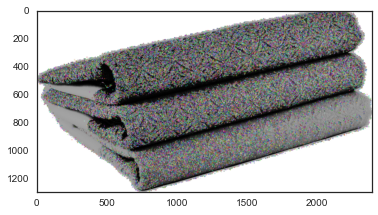

```
47651 descriptors, each of them has a length of 128
```

```python
# sift = cv2.xfeatures2d.SIFT_create()
sift = cv2.SIFT_create()
image = cv2.imread(descri.image_fullpath[1],0) # convert in gray
image = cv2.equalizeHist(image)   # equalize image histogram
kp, desc = sift.detectAndCompute(image, None)
img=cv2.drawKeypoints(image, kp, image)
plt.imshow(img)
plt.show()
print(desc.shape[0], 'descriptors, each of them has a length of', desc.shape[1])
```

### SIFT descriptors of all images

- Before seraching for descriptors - each image must be converted to grey and equalized;
- List of descriptors for every image - to be used for histogram/"bag of visual words" list creation;
- List of all descriptors, for all images - to be used in clustering.

Should I resize the images before making them grey and equalize? That could help with overloading the memory. There is a very large image at line 677. Its size is 8484 * 11042 pixels.

But as we see later, the quality of classification with SIFT is poor even without resizing. So for not rising question whether the poor result could be caused by wrong resizing, I just don't do the resizing to show that even the full images don't allow a good classification.

```python
# descri[descri.image == '5518124b75d6c6dfee4c2e4c0cfa716a.jpg']
```

```python
# identification of key points and associated descriptors
sift_keypoints = []
time1=time.time()
# sift = cv2.xfeatures2d.SIFT_create(500)

# sift = cv2.SIFT_create(500)
my_model = cv2.SIFT_create(500)

# for image_num in range(1050) :
for image_num in range(descri.shape[0]) :
    if image_num%100 == 0 : print(image_num, end='  ')
#     image = cv2.imread(descri.loc[image_num, 'image_fullpath'], 0) # convert in gray
    image = cv2.imread(descri.image_fullpath[image_num], 0) # convert in gray
    # image = cv2.cvtColor(image,cv2.COLOR_BGR2GRAY)
    image = cv2.equalizeHist(image)   # equalize image histogram
    kp, sift_signi_poi = my_model.detectAndCompute(image, None)
    sift_keypoints.append(sift_signi_poi)

duration1 = time.time()-time1
print('Time for creation of all SIFT descriptors : ', '%1.2f' % duration1, 'seconds')
```

```
0  100  200  300  400  500  600  700  800  900  1000  Time for creation of all SIFT descriptors :  599.07 seconds
```

```python
print(len(sift_keypoints))
test = [len(x) for x in sift_keypoints]
print(test[:10])
'''
elements in the list "sift keypoints" don't have equal length. Which should be 500, I suppose. Some are longer than 500,
some are shorter. That's why if I convert this list to a numpy array, I can use only object dtype, not float.
'''
pd.Series(test).value_counts()[:10]
```

```
1050
[500, 500, 500, 500, 500, 501, 501, 500, 500, 500]
```

```
500    786
501    191
502     13
503      4
330      3
249      2
239      2
462      1
114      1
508      1
dtype: int64
```

```python
# np.stack(np.asarray(sift_keypoints)) # ValueError: all input arrays must have the same shape

# sift_keypoints_by_img = np.array(sift_keypoints, dtype=float)
# sift_keypoints_by_img = np.asarray(sift_keypoints, dtype=float)
sift_keypoints_by_img = np.asarray(sift_keypoints, dtype=object)
sift_keypoints_all    = np.concatenate(sift_keypoints_by_img, axis=0) # shape (517351, 128)

print('Totally we have', sift_keypoints_all.shape[0], 'descriptors, each has the length', sift_keypoints_all.shape[1])
```

```
Totally we have 517351 descriptors, each has the length 128
```

### Create the "bag of visual words"

What's a visual word: it's a cluster of descriptors. We bring the descriptors to groups, using KMeans, or minibatch KMeans, or Gaussian mixture, or another algorithm. One "visual word" can be long (many descriptors), another can be short (1-2 descriptors, kind of a n outlier in the clustering).

Why else create the "bag of visual words" : for reducing the dimentionality of vocabulary. The size of vocabulary is 517,351 descriptors. I believe it's a sparce matrix, so maybe we could use Truncated SVD or SparcePca on it?) If we assign this vocabulary to the documents set, it will be either a 3D matrix, where to every document correspond a 2D (sparce) matrix of 517,351 * 128. Or if we flatten that 2D matrix, we obtain the vector of length 66,220,928 for every document.

So we pass from the space "coordinates of a descriptor(128) *number of all the descriptors for all the images (517,351)" to the space "arbitrarily chosen number of "visual words" (from 10* n_clusters = 10 * 7 = 70 to sqrt of 517,351 = 720)

```python
OMP_NUM_THREADS=4

# Determination number of clusters
time1=time.time()

k = int(np.sqrt(len(sift_keypoints_all)))
print('How many clusters/"visual words" do we have:', k)
print(k, 'clusters/"visual words" are being created...')

# Clustering
kmeans = cluster.MiniBatchKMeans(n_clusters=k, init_size=3*k, batch_size=2050)
kmeans.fit(sift_keypoints_all)

duration1 = time.time()-time1
print(k, 'clusters/"visual words" are created in', '%1.2f' % duration1, 'seconds')
```

```
How many clusters/"visual words" do we have: 719
719 clusters/"visual words" are being created...
719 clusters/"visual words" are created in 13.16 seconds
```

Every cluster is a "visual word", all together all the clusters are th "bag of visual words".

Now let's see how often each "word"(cluster) occurs in each "document"(image). We do an analog of CountVectorizer.

I suppose we don't have to divise by occurence of the cluster in the whole set of documents, to make an analogy of TfIdf Vectorizer, because these clusters are more unique than words of language (or not?)

```python
# Creation of histograms (features)
time1 = time.time()

def build_histogram(kmeans, descriptors, image_num):
    k = len(kmeans.cluster_centers_) # array length k defined in previous cell
    res = kmeans.predict(descriptors)
    hist = np.zeros(k) # array length k defined in previous cell
    nb_des = len(descriptors)
    if nb_des == 0 : print('No descriptors found for image #', image_num)
    for i in res:
        hist[i] += 1/nb_des
    return hist


# Creation of a matrix of histograms
hist_vectors=[]

for i, image_desc in enumerate(sift_keypoints_by_img) :
    if i % 100 == 0 : print(i, end=' ')
    hist = build_histogram(kmeans, image_desc, i) #calculates the histogram
    hist_vectors.append(hist) #histogram is the feature vector

SIFT_features = np.asarray(hist_vectors)

duration1=time.time()-time1
print('Histograms are created in ', '%1.2f' % duration1, 'seconds')
```

```
0 100 200 300 400 500 600 700 800 900 1000 Histograms are created in  54.34 seconds
```

### Dimensionality reduction

```python
print('Dimensions before PCA : ', SIFT_features.shape)
pca = PCA(n_components=0.95)
SIFT_pca = pca.fit_transform(SIFT_features)
print('Dimensions after PCA : ', SIFT_features.shape)

tsne = manifold.TSNE(n_components=2, perplexity=20, learning_rate='auto',
                     n_iter=2000, init='random')


# X_tsne = tsne.fit_transform(trans_arr) # max ARI 0.0, usually 0.02-0.03
SIFT_tsne = tsne.fit_transform(SIFT_features) # max ARI 0.07, usually 0.04-0.05

df_SIFT = pd.DataFrame(SIFT_tsne[:, 0:2], columns=['tsne1', 'tsne2'])
print(df_SIFT.shape)
```

```
Dimensions before PCA :  (1050, 719)
Dimensions after PCA :  (1050, 719)
(1050, 2)
```

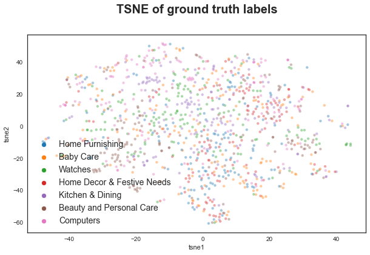

```python
plt.figure(figsize=(10,6))
sns.scatterplot(
    x='tsne1', y='tsne2',
    hue=orig_labels_names,
    palette=sns.color_palette('tab10', n_colors=7), s=20, alpha=0.4,
    data=df_SIFT,
    legend='brief')

plt.title('TSNE of ground truth labels', fontsize=20, pad=35, fontweight='bold')
# plt.xlabel('tsne1', fontsize=16, fontweight='bold')
# plt.ylabel('tsne2', fontsize=16, fontweight='bold')
plt.legend(prop={'size': 14})

plt.show()
```

Looks like the histograms don't reveal any structure. So, the very best we can hope is still quite close to 0. Let's check this hypothesis: try to make a clustering and evaluate with ground truth labels (ARI etc) and without them (Silhouette etc).

### Clusters

#### Based on PCA projection

```python
kmeans = cluster.KMeans(n_clusters=7)
kmeans.fit(SIFT_pca)

SIFT_pca_labels = kmeans.labels_
print(df_SIFT.shape)
```

```
(1050, 2)
```

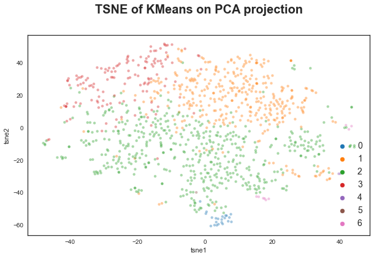

```
ARI : 0.03497749191222039
```

```python
plt.figure(figsize=(10,6))
sns.scatterplot(
    x='tsne1', y='tsne2',
    hue=SIFT_pca_labels,
    palette=sns.color_palette('tab10', n_colors=7), s=20, alpha=0.4,
    data=df_SIFT,
    legend='brief')

plt.title('TSNE of KMeans on PCA projection', fontsize=20, pad=35, fontweight='bold')
# plt.xlabel('tsne1', fontsize=16, fontweight = 'bold')
# plt.ylabel('tsne2', fontsize=16, fontweight = 'bold')
plt.legend(prop={'size': 14})
plt.show()

print('ARI :', metrics.adjusted_rand_score(orig_labels, SIFT_pca_labels))
```

```python
pd.Series(SIFT_pca_labels).value_counts()
```

```
2    511
1    367
3    138
0     22
6      9
4      2
5      1
dtype: int64
```

```python
print('ARI of KMeans labels', metrics.adjusted_rand_score(orig_labels, SIFT_pca_labels))
print('AMutual Info score of KMeans labels', metrics.adjusted_mutual_info_score(orig_labels, SIFT_pca_labels))
print('Homogeneity score of KMeans labels', metrics.homogeneity_score(orig_labels, SIFT_pca_labels))
print('Completeness score of KMeans labels', metrics.completeness_score(orig_labels, SIFT_pca_labels))
print('Fowlkes Mallows score of KMeans labels', metrics.fowlkes_mallows_score(orig_labels, SIFT_pca_labels))
print('Silhouette score of KMeans labels', metrics.silhouette_score(SIFT_pca, SIFT_pca_labels))
print('Davies-Bouldin index of KMeans labels', metrics.davies_bouldin_score(SIFT_pca, SIFT_pca_labels)) # when use redu_spa, TypeError: A sparse matrix was passed, but dense data is required. Use X.toarray() to convert to a dense numpy array.
print('Calinski-Harabasz score of KMeans labels', metrics.calinski_harabasz_score(SIFT_pca, SIFT_pca_labels)) # when use redu_spa, TypeError: A sparse matrix was passed, but dense data is required. Use X.toarray() to convert to a dense numpy array.
```

```
ARI of KMeans labels 0.03497749191222039
AMutual Info score of KMeans labels 0.05246652889173368
Homogeneity score of KMeans labels 0.04956426307953243
Completeness score of KMeans labels 0.08573520880912142
Fowlkes Mallows score of KMeans labels 0.26228616833443064
Silhouette score of KMeans labels 0.01829476146400346
Davies-Bouldin index of KMeans labels 2.207492626187628
Calinski-Harabasz score of KMeans labels 52.82534939043094
```

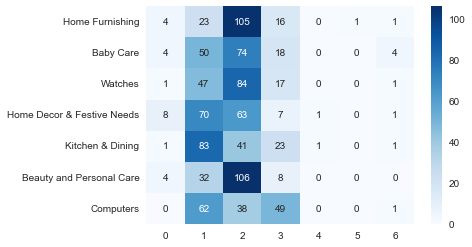

```python
conf_mat = metrics.confusion_matrix(orig_labels, SIFT_pca_labels)
df_cm = pd.DataFrame(conf_mat, index = [label for label in labels_names])
plt.figure()
ax3 = sns.heatmap(df_cm, annot=True, cmap='Blues', fmt='g')
plt.show()
# print(metrics.classification_report(labels, cls_labels_transform))
```

#### Based on t-SNE projection

```python
kmeans = cluster.KMeans(n_clusters=7)
kmeans.fit(SIFT_tsne)

SIFT_tsne_labels = kmeans.labels_
print(df_SIFT.shape)
```

```
(1050, 2)
```

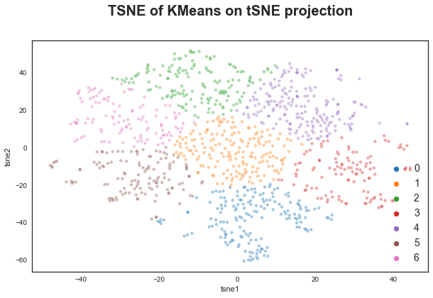

```
ARI :  0.0455672407008255
```

```python
plt.figure(figsize=(10,6))
sns.scatterplot(
    x='tsne1', y='tsne2',
    hue=SIFT_tsne_labels,
    palette=sns.color_palette('tab10', n_colors=7), s=20, alpha=0.4,
    data=df_SIFT,
    legend='brief')

plt.title('TSNE of KMeans on tSNE projection', fontsize = 20, pad = 35, fontweight = 'bold')
# plt.xlabel('tsne1', fontsize=16, fontweight = 'bold')
# plt.ylabel('tsne2', fontsize=16, fontweight = 'bold')
plt.legend(prop={'size': 14})

plt.show()

print('ARI : ', metrics.adjusted_rand_score(orig_labels, SIFT_tsne_labels))
```

```python
pd.Series(SIFT_tsne_labels).value_counts()
```

```
4    192
1    179
0    171
2    152
5    129
3    115
6    112
dtype: int64
```

```python
print('ARI of KMeans labels', metrics.adjusted_rand_score(orig_labels, SIFT_tsne_labels))
print('AMutual Info score of KMeans labels', metrics.adjusted_mutual_info_score(orig_labels, SIFT_tsne_labels))
print('Homogeneity score of KMeans labels', metrics.homogeneity_score(orig_labels, SIFT_tsne_labels))
print('Completeness score of KMeans labels', metrics.completeness_score(orig_labels, SIFT_tsne_labels))
print('Fowlkes Mallows score of KMeans labels', metrics.fowlkes_mallows_score(orig_labels, SIFT_tsne_labels))
print('Silhouette score of KMeans labels', metrics.silhouette_score(SIFT_tsne, SIFT_tsne_labels))
print('Davies-Bouldin index of KMeans labels', metrics.davies_bouldin_score(SIFT_tsne, SIFT_tsne_labels)) # when use redu_spa, TypeError: A sparse matrix was passed, but dense data is required. Use X.toarray() to convert to a dense numpy array.
print('Calinski-Harabasz score of KMeans labels', metrics.calinski_harabasz_score(SIFT_tsne, SIFT_tsne_labels)) # when use redu_spa, TypeError: A sparse matrix was passed, but dense data is required. Use X.toarray() to convert to a dense numpy array.
```

```
ARI of KMeans labels 0.0455672407008255
AMutual Info score of KMeans labels 0.06571665391415651
Homogeneity score of KMeans labels 0.07370502893931363
Completeness score of KMeans labels 0.074460244680243
Fowlkes Mallows score of KMeans labels 0.18378652863181824
Silhouette score of KMeans labels 0.37766412
Davies-Bouldin index of KMeans labels 0.7984741063281403
Calinski-Harabasz score of KMeans labels 953.9469813364149
```

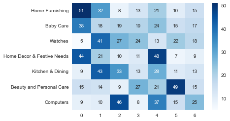

```python
conf_mat = metrics.confusion_matrix(orig_labels, SIFT_tsne_labels)
df_cm = pd.DataFrame(conf_mat, index = [label for label in labels_names])
plt.figure()
ax3 = sns.heatmap(df_cm, annot=True, cmap='Blues', fmt='g')
plt.show()
# print(metrics.classification_report(labels, cls_labels_transform))
```

# Pre-trained VGG16 with all layers (including classifier of 1000 classes)

```python
vgg16_model = VGG16()
vgg16_model
```

```
<tensorflow.python.keras.engine.functional.Functional at 0x2670bbf7a00>
```

## Example of 1 image converted to vector

Thie following code works. I commented it out because it's useless for the treatment of the data

```python
# img0 = load_img(path_images + '00e966a5049a262cfc72e6bbf68b80e7.jpg', target_size=(224, 224))  # Charger l'image
# img0

# img1 = img_to_array(img0)  # Convertir en tableau numpy
# print(img1.dtype, img1.shape)
# img1[0][:3]

# img2 = img1.reshape((1, img1.shape[0], img1.shape[1], img1.shape[2]))
# print(img2.dtype, img2.shape)
# img2[0][0][:3]

# img3 = preprocess_input(img2)
# print(img2.dtype, img2.shape)
# img3[0][0][:3]
```

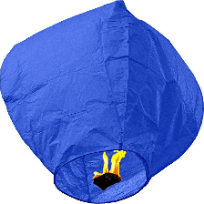

```python
img = load_img(path_images + '0a3b5fdf77a361c2d7d9b29c259b8c4e.jpg', target_size=(224, 224))  # Load the image
display(img)
img = img_to_array(img)  # Convertir en tableau numpy
img = img.reshape((1, img.shape[0], img.shape[1], img.shape[2]))  # Make a collection of images (1 sample, 1 image)
img = preprocess_input(img)  # Preprocess the image as VGG-16 wants

img = vgg16_model.predict(img)  # Predict image class (of 1000 classes of ImageNet)
# The result is a vector: a list of length 1000, each coordinate is a probability for a given class
# On obtient le résultat du réseau, c'est-à-dire un vector, une liste de 1000 probabilités.
```

```python
# Afficher les 3 classes les plus probables
print('Top 3 :', decode_predictions(img, top=3)[0])
```

```
Top 3 : [('n04235860', 'sleeping_bag', 0.97583437), ('n04209133', 'shower_cap', 0.014998215), ('n04370456', 'sweatshirt', 0.0019061128)]
```

## Apply the procedure to all images, convert to vectors of 1000 classes probabilities

```
<class 'pandas.core.series.Series'> object
```

[figure not shown]

```python
test1 = descri.image_fullpath.map(lambda x: load_img(x, target_size=(224, 224)))
print(type(test1), test1.dtype) # test1[i] doesn't have a shape, it's an image
display(test1[677]) # this image originally had size 8484 * 11,042 pixels
```

```python
test1 = test1.map(lambda x: img_to_array(x))
print(type(test1), test1.dtype, 'shape', test1[0].shape)
test1[0][0][:2]
```

```
<class 'pandas.core.series.Series'> object shape (224, 224, 3)
```

```
array([[206., 204., 192.],
       [205., 203., 191.]], dtype=float32)
```

```python
test2 = test1.map(lambda x: x.reshape((1, x.shape[0], x.shape[1], x.shape[2]))) # Make a collection of images (1 sample, 1 image)
print(type(test2), test2.dtype, 'shape', test2[0].shape)
test2[0][0][0][:3]
```

```
<class 'pandas.core.series.Series'> object shape (1, 224, 224, 3)
```

```
array([[206., 204., 192.],
       [205., 203., 191.],
       [205., 202., 193.]], dtype=float32)
```

```python
test3 = test2.map(lambda x: preprocess_input(x))
print(type(test2), test2.dtype, 'shape', test2[0].shape)
test3[0][0][0][:3]
```

```
<class 'pandas.core.series.Series'> object shape (1, 224, 224, 3)
```

```
array([[88.061, 87.221, 82.32 ],
       [87.061, 86.221, 81.32 ],
       [89.061, 85.221, 81.32 ]], dtype=float32)
```

```python
time1 = time.time()
test4 = test3.map(lambda x: vgg16_model.predict(x))

print(f'prediction of 1000 probabilities for 1050 images is done in {time.time() - time1} seconds.')
```

```
prediction of 1000 probabilities for 1050 images is done in 314.95488929748535 seconds.
```

```python
test4 = test4.map(lambda x: x[0]) #remove the "envelop" of the array; convert a collection to a single image
```

```python
VGG16_probabilities = np.stack(test4.values)
VGG16_probabilities.shape
```

```
(1050, 1000)
```